# Day 18: Boosting — In-Class Activity (Solutions)

Is this patient at risk? Small trees, one after another.

Instructor

```r
# Count each patient's risk factors (the true rule depends only on this count)
count_factors <- function(data) {
  data %>%
    mutate(risk_factors = smoker + high_bp + high_chol + diabetes + inactive +
                          overweight + family_history + over_60 + poor_diet + heavy_drinker)
}

# n patients with 10 yes/no risk factors each (1 = yes, 0 = no)
make_patients <- function(n) {
  factors <- c("smoker", "high_bp", "high_chol", "diabetes", "inactive",
               "overweight", "family_history", "over_60", "poor_diet", "heavy_drinker")
  matrix(rbinom(n * 10, 1, 0.4), nrow = n, dimnames = list(NULL, factors)) %>%
    as_tibble() %>%
    count_factors() %>%
    mutate(at_risk = factor(if_else(runif(n) < plogis(2 * (risk_factors - 4.5)), "Yes", "No"))) %>%
    select(-risk_factors)             # the methods don't get to see the count
}
set.seed(18)
patients <- make_patients(1000)       # training patients
new_patients <- make_patients(5000)   # test patients

# gbm wants a 0/1 outcome; also give each patient one of 5 folds (Part 2)
patients01 <- patients %>%
  mutate(at_risk = if_else(at_risk == "Yes", 1, 0),
         fold = sample(rep(1:5, length.out = n())))
```

### A first look at the data

```r
patients %>%
  head(6) %>%
  count_factors() %>%
  mutate(chance = round(plogis(2 * (risk_factors - 4.5)), 2)) %>%   # the true chance of being at risk
  mutate(patient = 1:6) %>%
  select(patient, risk_factors, chance, at_risk, everything()) %>%   # put the new columns first
  knitr::kable()                                                    # print as a table
```

| patient | risk_factors | chance | at_risk | smoker | high_bp | high_chol | diabetes | inactive | overweight | family_history | over_60 | poor_diet | heavy_drinker |
| --- | --- | --- | --- | --- | --- | --- | --- | --- | --- | --- | --- | --- | --- |
| 1 | 2 | 0.01 | No | 1 | 0 | 0 | 0 | 0 | 0 | 0 | 1 | 0 | 0 |
| 2 | 4 | 0.27 | No | 1 | 1 | 1 | 0 | 0 | 0 | 0 | 0 | 0 | 1 |
| 3 | 5 | 0.73 | Yes | 1 | 0 | 0 | 1 | 0 | 1 | 0 | 0 | 1 | 1 |
| 4 | 3 | 0.05 | No | 0 | 0 | 0 | 0 | 0 | 1 | 0 | 1 | 1 | 0 |
| 5 | 3 | 0.05 | No | 0 | 1 | 0 | 1 | 0 | 1 | 0 | 0 | 0 | 0 |
| 6 | 3 | 0.05 | No | 0 | 0 | 1 | 0 | 0 | 0 | 0 | 1 | 0 | 1 |

```r
patients %>%
  count_factors() %>%
  group_by(risk_factors) %>%
  summarise(patients = n(), share_at_risk = mean(at_risk == "Yes"))
```

```
## # A tibble: 10 × 3
##    risk_factors patients share_at_risk
##           <int>    <int>         <dbl>
##  1            0        1       0
##  2            1       41       0
##  3            2      115       0.00870
##  4            3      241       0.0747
##  5            4      238       0.252
##  6            5      208       0.697
##  7            6       99       0.939
##  8            7       42       1
##  9            8       11       1
## 10            9        4       1
```

Patient 3 has 5 risk factors (smoker, diabetes, overweight, poor diet, heavy drinker), so a 73% chance, and turned out to be at risk. Patient 2 has 4, so a 27% chance, and wasn’t. In the second table the share at risk is about 0% with 2 or fewer factors, 7% with 3, 25% with 4, 70% with 5, and 94% or more from 6 on. The big jump is between 4 and 5 factors.

## Part 1: Boosting by Hand

```r
lambda <- 0.1
by_hand <- patients %>%
  count_factors() %>%
  select(-at_risk) %>%
  mutate(model = mean(risk_factors))                       # start at the average
splits <- c()                                              # the factor each stump asks about
fits <- tibble()
for (b in 1:100) {
  by_hand <- by_hand %>% mutate(resid = risk_factors - model)   # what the model still gets wrong
  stump <- rpart(resid ~ ., data = select(by_hand, -risk_factors, -model),
                 maxdepth = 1, cp = 0)                           # a stump: one split
  splits <- c(splits, as.character(stump$frame$var[1]))
  by_hand <- by_hand %>% mutate(model = model + lambda * predict(stump, by_hand))
  if (b %in% c(1, 10, 100)) fits <- bind_rows(fits, by_hand %>% mutate(trees = b))
}

splits[1:12]       # the first 12 stumps
```

```
##  [1] "poor_diet"      "over_60"        "overweight"     "poor_diet"
##  [5] "high_chol"      "diabetes"       "over_60"        "high_bp"
##  [9] "smoker"         "heavy_drinker"  "family_history" "overweight"
```

```r
table(splits)      # all 100
```

```
## splits
##       diabetes family_history  heavy_drinker        high_bp      high_chol
##             10             10             10             10             10
##       inactive        over_60     overweight      poor_diet         smoker
##             10             10             10             10             10
```

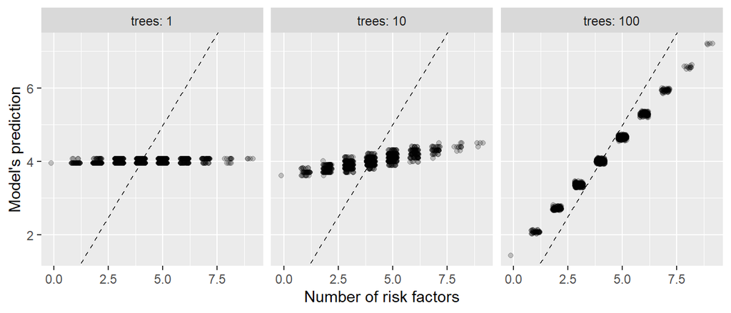

```r
fits %>%
  ggplot(aes(risk_factors, model)) +
  geom_jitter(width = 0.2, height = 0, alpha = 0.2) +
  geom_abline(slope = 1, intercept = 0, linetype = "dashed") +   # a perfect count
  facet_wrap(~ trees, labeller = label_both) +
  labs(x = "Number of risk factors", y = "Model's prediction")
```

After 1 tree the model makes only **two** predictions: the first stump asks “poor_diet?” and moves those patients a little up and everyone else a little down. The first 12 stumps ask about 9 different factors, and over all 100 stumps **each factor gets asked exactly 10 times**: once a stump has used poor_diet, its residuals no longer depend much on poor_diet, so the next stump finds a different factor more useful.

After 100 trees the points line up on a **straight line**: the model has learned to count. Every stump adds a small amount for one factor, so the model is a sum, one piece per factor. It isn’t on the dashed line yet (2.7 for 2 factors, 6.6 for 8): each factor has been added in only 10 small steps of $\lambda$ = 0.1. More trees would move it the rest of the way; that’s why a small $\lambda$ needs a large $B$.

## Part 2: Tuning

### Task 2.1: A CV function for boosting

```r
B_grid <- c(10, 50, 100, 200, 500, 1000, 2000, 5000)

cv_boost <- function(d, lambda) {
  fold_errors <- tibble()
  for (f in 1:5) {
    train <- patients01 %>% filter(fold != f) %>% select(-fold)
    test  <- patients01 %>% filter(fold == f)
    set.seed(f)
    boost <- gbm(at_risk ~ ., data = train,
                 distribution = "bernoulli",   # Yes/No outcome
                 n.trees = 5000,               # B: the most we score
                 shrinkage = lambda,           # lambda
                 interaction.depth = d)        # d
    prob <- predict(boost, test, n.trees = B_grid, type = "response")  # one column per B
    fold_errors <- bind_rows(fold_errors,
                             tibble(fold = f, B = B_grid,
                                    error = colMeans((prob > 0.5) != (test$at_risk == 1))))
  }
  fold_errors %>%
    group_by(B) %>%
    summarise(cv_error = mean(error), se = sd(error) / sqrt(5)) %>%
    mutate(d = d, lambda = lambda, .before = 1)
}
```

### Task 2.2: Three settings

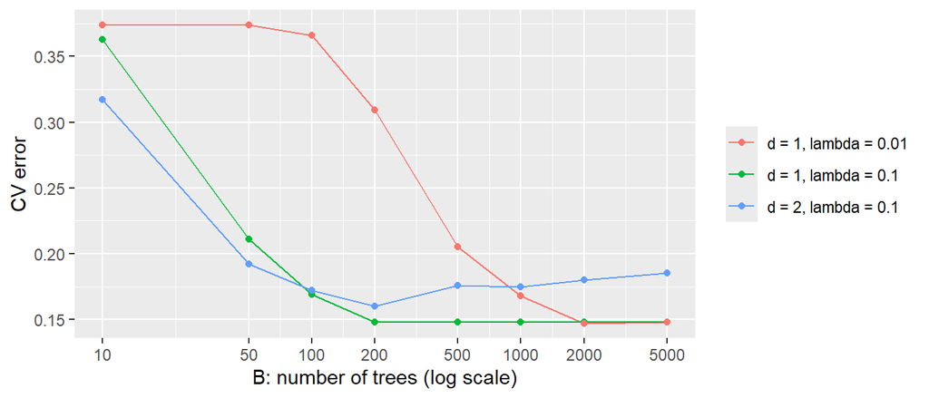

```r
all_settings <- bind_rows(
  cv_boost(d = 1, lambda = 0.1),
  cv_boost(d = 1, lambda = 0.01),
  cv_boost(d = 2, lambda = 0.1)
)

all_settings %>%
  mutate(setting = paste0("d = ", d, ", lambda = ", lambda)) %>%
  ggplot(aes(B, cv_error, color = setting)) +
  geom_line() +
  geom_point() +
  scale_x_log10(breaks = B_grid) +
  labs(x = "B: number of trees (log scale)", y = "CV error", color = NULL)
```

```r
all_settings %>% slice_min(cv_error, n = 1)     # the best setting (all of them, if there is a tie)
```

```
## # A tibble: 1 × 5
##       d lambda     B cv_error     se
##   <dbl>  <dbl> <dbl>    <dbl>  <dbl>
## 1     1   0.01  2000    0.147 0.0135
```

With stumps and $\lambda$ = 0.1, the error falls quickly and then stays **flat** at about 14.8% from 200 trees on. With $\lambda$ = 0.01 the steps are 10 times smaller, so it needs about 10 times as many trees: it is still at 20.5% after 500 and reaches 14.7% at 2,000. The two end up in the same place, a tie (the SEs are about 1.4 points). The best setting in the table is $d$ = 1, $\lambda$ = 0.01, $B$ = 2,000; $\lambda$ = 0.1 with 200 trees is just as good and 10 times faster.

Two splits per tree ($d$ = 2) **don’t help**: they reach 16.0% at 200 trees, then the error **rises** to 18.5% at 5,000. Boosting can overfit because each new tree fits what the earlier ones got wrong, including the noise; a forest’s trees are each grown on their own and averaged, so more of them never hurts. Two-split trees can learn combinations (“smoker **and** over 60”), but here the risk depends only on the **count**, a sum of separate pieces, so those combinations are mostly noise. Stumps can’t overfit much here: a sum of one piece per factor is already the right shape.

## Part 3: The Scoreboard

```r
test_error <- function(pred) mean(pred != new_patients$at_risk)

tree <- rpart(at_risk ~ ., data = patients, method = "class")

set.seed(18)
bag <- randomForest(at_risk ~ ., data = patients, ntree = 500, mtry = 10)
set.seed(18)
forest <- randomForest(at_risk ~ ., data = patients, ntree = 500)

set.seed(18)
boost <- gbm(at_risk ~ ., data = select(patients01, -fold), distribution = "bernoulli",
             n.trees = 2000, shrinkage = 0.01, interaction.depth = 1)
boost_prob <- predict(boost, new_patients, n.trees = boost$n.trees, type = "response")

true_count <- new_patients %>% count_factors() %>% pull(risk_factors)

tibble(
  method = c("one tree", "bagging", "random forest", "boosting",
             "the true rule (5 or more factors)"),
  test_error = c(test_error(predict(tree, new_patients, type = "class")),
                 test_error(predict(bag, new_patients)),
                 test_error(predict(forest, new_patients)),
                 test_error(if_else(boost_prob > 0.5, "Yes", "No")),
                 test_error(if_else(true_count >= 5, "Yes", "No")))
)
```

```
## # A tibble: 5 × 2
##   method                            test_error
##   <chr>                                  <dbl>
## 1 one tree                               0.265
## 2 bagging                                0.200
## 3 random forest                          0.183
## 4 boosting                               0.135
## 5 the true rule (5 or more factors)      0.135
```

## Part 4: Why Boosting Wins Here

```r
new_patients %>%
  count_factors() %>%
  mutate(forest_prob = predict(forest, new_patients, type = "prob")[, "Yes"],
         boost_prob = boost_prob,
         forest_pred = if_else(forest_prob > 0.5, "Yes", "No"),
         boost_pred = if_else(boost_prob > 0.5, "Yes", "No"),
         true_rule = if_else(risk_factors >= 5, "Yes", "No")) %>%
  group_by(risk_factors) %>%
  summarise(patients = n(),
            forest_low = quantile(forest_prob, 0.1),     # 10% of patients get less than this
            forest_high = quantile(forest_prob, 0.9),    # 10% get more than this
            boost_low = quantile(boost_prob, 0.1),
            boost_high = quantile(boost_prob, 0.9),
            forest_off = mean(forest_pred != true_rule),   # share where it disagrees with the true rule
            boost_off = mean(boost_pred != true_rule)) %>%
  mutate(across(where(is.double), ~ round(.x, 2)))
```

```
## # A tibble: 10 × 8
##    risk_factors patients forest_low forest_high boost_low boost_high forest_off
##           <int>    <int>      <dbl>       <dbl>     <dbl>      <dbl>      <dbl>
##  1            0       27       0           0         0          0          0
##  2            1      203       0           0         0.01       0.01       0
##  3            2      599       0           0.02      0.03       0.04       0
##  4            3     1102       0.01        0.2       0.09       0.14       0.01
##  5            4     1244       0.12        0.5       0.27       0.37       0.1
##  6            5     1005       0.3         0.75      0.56       0.68       0.36
##  7            6      555       0.57        0.9       0.81       0.88       0.04
##  8            7      216       0.85        0.97      0.94       0.96       0
##  9            8       42       0.93        0.99      0.98       0.99       0
## 10            9        7       0.99        1         1          1          0
## # ℹ 1 more variable: boost_off <dbl>
```

The forest’s mistakes are almost all patients with **4 or 5** risk factors, right at the line: it says “No” to 36% of the patients with 5 factors and “Yes” to 10% of those with 4. Boosting agrees with the true rule for **every** test patient.

The true chance depends only on the count, so all patients with 5 factors should get the same probability (0.73). Boosting gives most of them something between 0.56 and 0.68. The forest gives them anything from 0.30 to 0.75, depending on **which** five they have.

Each forest tree follows one path of questions (“smoker? then over 60? then …”) and puts the patient in a leaf. To count to 5 it would need a path through all ten factors and a leaf for every combination, with only a few training patients in each, and the averaged trees still don’t add up to a count. Each boosted stump adds a little for **one** factor, so the boosted model is a sum over the factors, which is exactly the shape of a count.

On Day 17’s suburbs the forest won because there the pattern was a few **thresholds and interactions** (high-crime suburbs at `rad` = 24, or at moderate `nox` with some `rad` values), which is what a tree’s path of questions captures well.

## Bonus

### Bonus 1: Can tuning save the forest?

```r
mtrys <- c(1, 2, 5)
mtry_err <- rep(NA, length(mtrys))
for (i in 1:length(mtrys)) {
  set.seed(18)
  fit <- randomForest(at_risk ~ ., data = patients, ntree = 500, mtry = mtrys[i])
  mtry_err[i] <- test_error(predict(fit, new_patients))
}
tibble(mtry = mtrys, test_error = mtry_err)
```

```
## # A tibble: 3 × 2
##    mtry test_error
##   <dbl>      <dbl>
## 1     1      0.258
## 2     2      0.186
## 3     5      0.195
```

### Bonus 2: Boosting on Day 17’s suburbs

```r
data(Boston)
boston01 <- Boston %>%
  mutate(HighCrime = if_else(crim > median(crim), 1, 0)) %>%
  select(-crim)
boost_cv <- rep(NA, 3)
for (s in 1:3) {
  set.seed(s)
  boston_s <- boston01 %>% mutate(fold = sample(rep(1:5, length.out = n())))
  errors <- rep(NA, 5)
  for (f in 1:5) {
    train <- boston_s %>% filter(fold != f) %>% select(-fold)
    test  <- boston_s %>% filter(fold == f)
    set.seed(f)
    b <- gbm(HighCrime ~ ., data = train, distribution = "bernoulli",
             n.trees = 1000, shrinkage = 0.01, interaction.depth = 2)
    p <- predict(b, test, n.trees = 1000, type = "response")
    errors[f] <- mean((p > 0.5) != (test$HighCrime == 1))
  }
  boost_cv[s] <- mean(errors)
}
boost_cv
```

```
## [1] 0.04929140 0.05136867 0.04938847
```

```r
mean(boost_cv)
```

```
## [1] 0.05001618
```

On the suburbs, boosting’s CV error is **5.0%**, worse than Day 17’s random forest (4.1%) and about the same as bagging (5.1%). There the pattern is a few strong thresholds (`nox` near 0.53, `rad` of 24) and an interaction between them. Full-size forest trees capture those in a few splits each. Boosting’s small trees have to build those sharp cuts one small step at a time. In the patient data the pattern is a count, a sum of one piece per factor, which is exactly what boosted stumps build.

### Bonus 3: Which risk factors does boosting use?

```r
summary(boost, plotit = FALSE)
```

```
##                           var   rel.inf
## overweight         overweight 13.409365
## poor_diet           poor_diet 11.590766
## over_60               over_60 11.530381
## high_chol           high_chol 10.846462
## smoker                 smoker 10.300680
## diabetes             diabetes  9.523820
## family_history family_history  9.329866
## heavy_drinker   heavy_drinker  8.473614
## inactive             inactive  7.830746
## high_bp               high_bp  7.164300
```

The relative influence is spread over all ten factors, each between 7% and 13%. That matches the true rule, where every factor counts the same; the differences are noise in 1,000 patients.